# ALS_Dream_Challenge: Clusters_Feature_Selector

**C. Weight and Forced Vital Capacity**

There are various ALS symptoms that manifest in patients at different times points of the disease progression. Regardless, one of the main symptoms is weight loss which is due to muscle atrophy, weakness, and reduced physical activity. Another is difficulty of breathing due to impaired breathing function. As a matter of fact, it is the main cause of death of ALS patients.

One of the main assessment protocols to measure respiration functionality is the Forced Vital Capacity. Specifically, it is defined as the total volume of air (in liters) that the patient can expire after inspiration. In scientific literature, FVC is typically recorded in percentage form (100% considered as normal, 80% as deteriorating, and 50% as very low breathing function which possibly indicates the need for the assistance of a ventilator), but the PRO-ACT reported FVC mainly in liters.

That being said, we wanted to explore the average weights and FVC of patients in cluster 1 and cluster 2, if there is any.

```r
ALSFRS_Average <-  features_eda %>% group_by(Cluster_Number) %>% summarise( Average_Creatinine=mean(Creatinine), Average_FVC=mean(Subject_Liters_Trial_1), Average_Weight=mean(Weight))
as.data.frame(ALSFRS_Average)
```

```
##   Cluster_Number Average_Creatinine Average_FVC Average_Weight
## 1              1           64.07753    3.146910       67.32970
## 2              2           72.03085    3.194036       73.90819
```

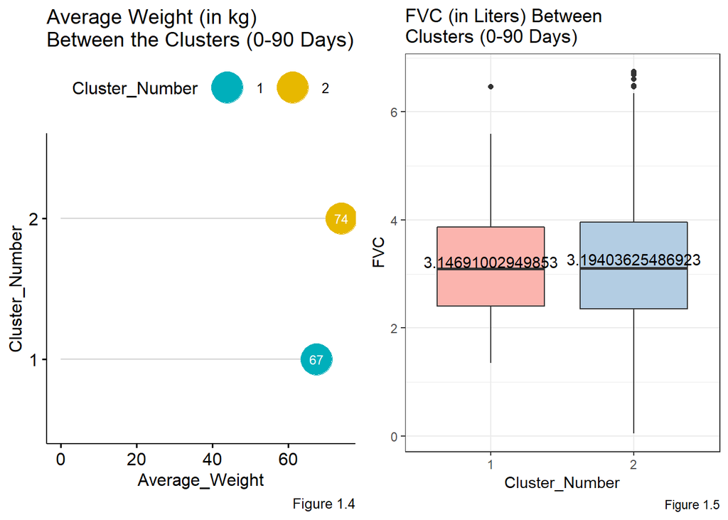

```r
#weight
weight <- ggdotchart(ALSFRS_Average, x = "Cluster_Number", y = "Average_Weight",
           color = "Cluster_Number",                                #
           palette = c("#00AFBB", "#E7B800"),
           sorting = "descending",
           add = "segments",
           rotate = TRUE,
           group = "Cluster_Number",
           dot.size = 10,
           label = round(ALSFRS_Average$Average_Weight),
           font.label = list(color = "white", size = 9, vjust = 0.5),
           ggtheme = theme_pubr()) +labs(title = "Average Weight (in kg)
Between the Clusters (0-90 Days)", caption = "Figure 1.4")
#FVC
FVC <- ggplot(data = features_eda, aes( x = Cluster_Number, y =Subject_Liters_Trial_1 , fill = Cluster_Number)) + geom_boxplot() + scale_fill_brewer(palette="Pastel1")+labs(title = "FVC (in Liters) Between
Clusters (0-90 Days)", x = "Cluster_Number", y = "FVC", fill="Cluster_Number", caption = "Figure 1.5") +  theme_bw() +geom_text(data = ALSFRS_Average, aes(label = Average_FVC, y = Average_FVC + 0.08))
grid.arrange(weight, FVC+theme(legend.position = 'none'), widths=c(2,2), ncol=2)
```

**D. Creatinine**

The last variable we wanted compare between the 2 clusters is creatinine. Although this blood test is mainly used to gauge kidney function, creatinine has been recently linked to ALS progression and survival according to a study in the University of Turin in Italy. The normal range for creatinine is approxmitately 53-106 mmol/L. In general, the lower the creatinine values, the poorer the prognosis and survival rate of the patient.

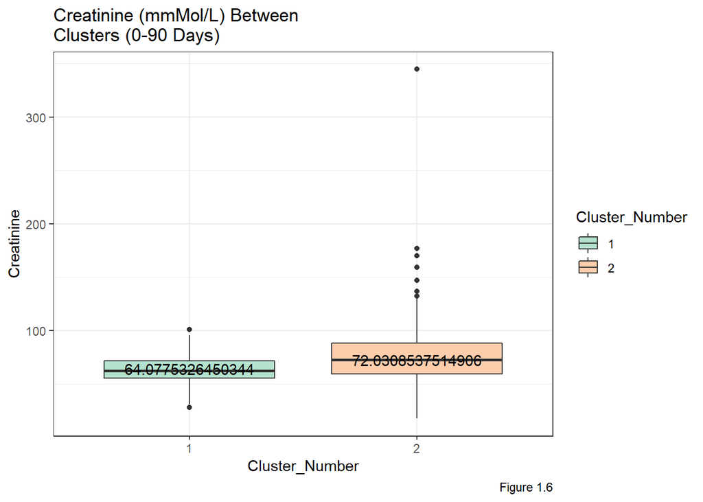

```r
Creatinine <- ggplot(data = features_eda, aes( x = Cluster_Number, y =Creatinine , fill = Cluster_Number)) + geom_boxplot() + scale_fill_brewer(palette="Pastel2")+labs(title = "Creatinine (mmMol/L) Between
Clusters (0-90 Days)", x = "Cluster_Number", y = "Creatinine", fill="Cluster_Number", caption = "Figure 1.6") +  theme_bw() +geom_text(data = ALSFRS_Average, aes(label = Average_Creatinine, y = Average_Creatinine + 0.50))
Creatinine
```

As seen above, patients in cluster 2 have a higher average of creatinine levels of 72.03 than in patients in cluster 1 (64.07).

Altogether, cluster 1 patients are characterized by a lower 0-3 Month ALSFRS Score, Forced Vital Capacity, Weight, and Creatinine levels than in patients in cluster 2. Needless to say, these factors convey that cluster 1 may likely have a poorer prognosis and survival rate than patients in cluster 2.